# Lesson 5 - Exploring Two Variables

### Scatterplots and Perceived Audience Size

Notes:

### Scatterplots

Notes:

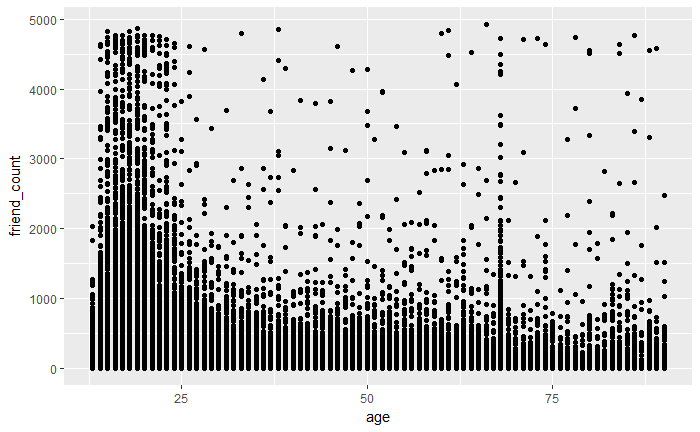

#### What are some things that you notice right away?

Response: - People under the age of age have far more friends that people over 30. - People over age 90 have surprisingly more friends. ***

### Overplotting

Notes: - SOme points are spread out. - Some are stacked on top of each other. - Use alpha parameter 1/20 -> It will take 20 points to be equivalent of one data point. - Age is a continuous variable, but in the graph it appears to be.. To add the effect of continuity, use jitter to add noise. Observe the difference.

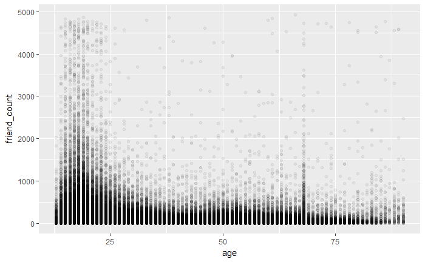

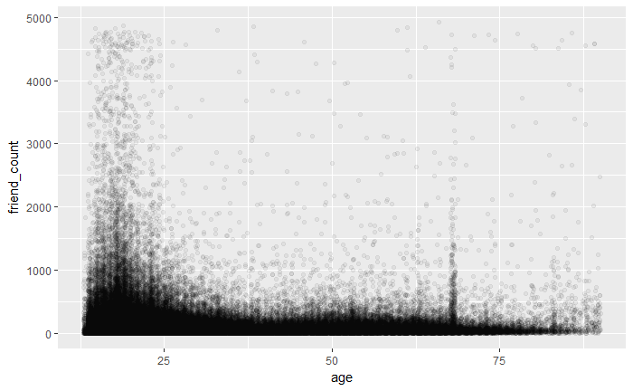

#### What do you notice in the plot?

Response: - The bulk of users have really have friend counts less than 1000.

### Coord_trans()

Notes: - To get a better visualisation of the data, limit y axis

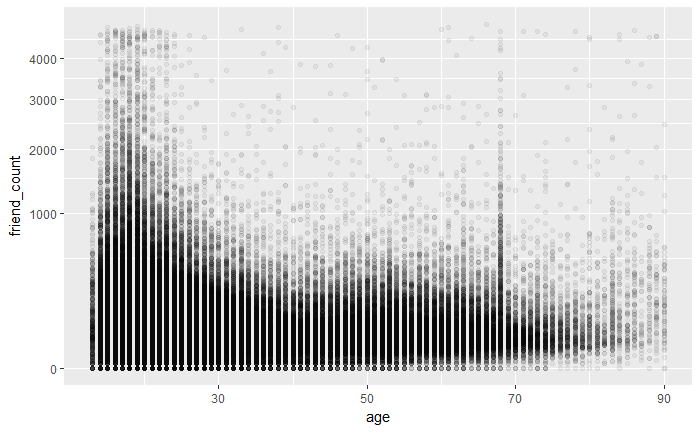

#### What do you notice?

- Easier to see the friend count.
- Cant use jitter directly. Some people have 0 friend count. They would have imaginary values after sqrt application. TO add jitter use geom_point(position = position_jitter())

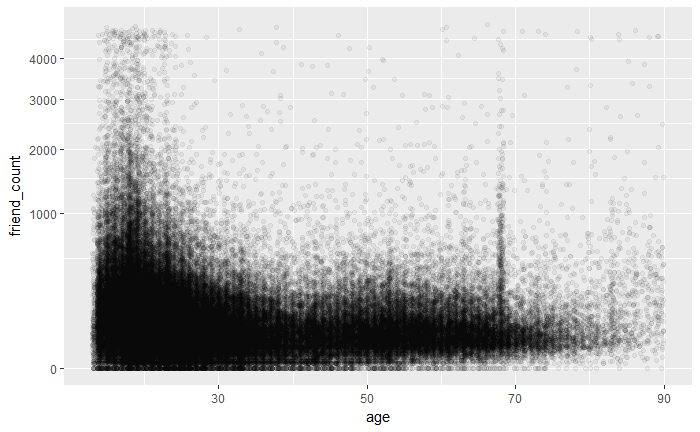

### Alpha and Jitter

Notes: - Explore relationship between friendship initiated and age

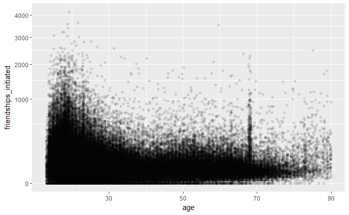

### Overplotting and Domain Knowledge

Notes: - Make adjustments to scatter plot even further !! - Transform axis into percentages to better understand data. - ***

### Conditional Means

Notes: - Summarize relationship between 2 variables. - Scatterplot doesnt really help us understand the intricacies. - ‘dplyr’ helps split the dataframe and apply functions to it.

| age | friend_count_mean | friend_count_median | n |
| --- | --- | --- | --- |
| 13 | 164.75000 | 74.0 | 484 |
| 14 | 251.39013 | 132.0 | 1925 |
| 15 | 347.69213 | 161.0 | 2618 |
| 16 | 351.93714 | 171.5 | 3086 |
| 17 | 350.30064 | 156.0 | 3283 |
| 18 | 331.16628 | 162.0 | 5196 |
| 19 | 333.69210 | 157.0 | 4391 |
| 20 | 283.49907 | 135.0 | 3769 |
| 21 | 235.94116 | 121.0 | 3671 |
| 22 | 211.39479 | 106.0 | 3032 |

[output cut: 91 more lines]

Create your plot! Average friend_count vs Age

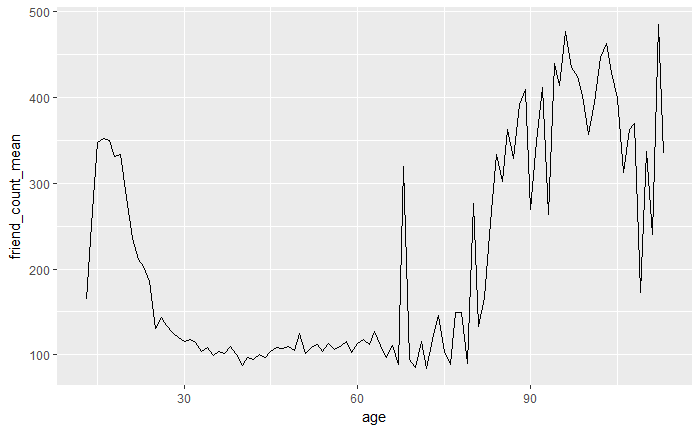

### Overlaying Summaries with Raw Data

Notes:

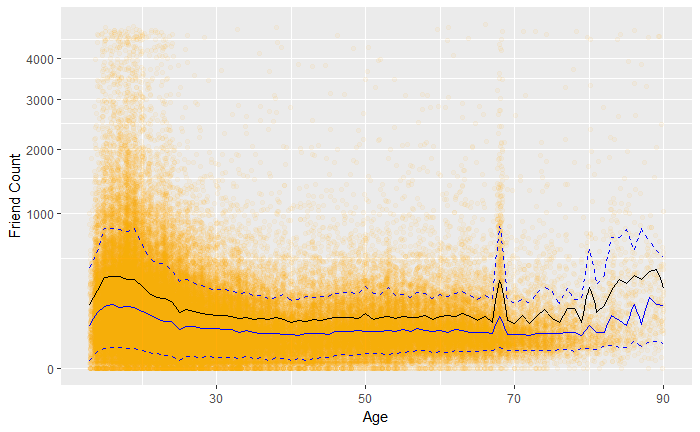

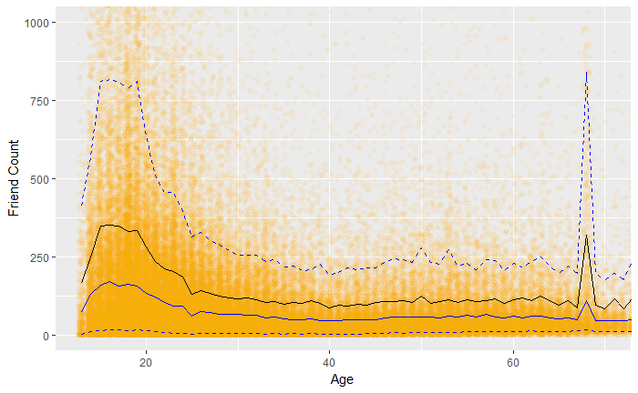

#### What are some of your observations of the plot?

Response: - Having more than 1000 frineds is rare. - For 35-50 yr olds, friend_count falls below 50 -

### Moira: Histogram Summary and Scatterplot

See the Instructor Notes of this video to download Moira’s paper on perceived audience size and to see the final plot.

Notes:

### Correlation

Notes: - Summarise the strength of ther elationship using a single number. - Use pearson_product relation coefficient - Rule of thumb: - |correlation| > 0.3 is meaningful but small - |correlation| > 0.5 is moderate - |correlation| > 0.7 is pretty large

```r
with(pf, cor.test(age, friend_count, method='pearson'))
```

```
    Pearson's product-moment correlation

data:  age and friend_count
t = -8.6268, df = 99001, p-value < 2.2e-16
alternative hypothesis: true correlation is not equal to 0
95 percent confidence interval:
 -0.03363072 -0.02118189
sample estimates:
        cor
-0.02740737
```

Look up the documentation for the cor.test function.

What’s the correlation between age and friend count? Round to three decimal places. Response:

### Correlation on Subsets

Notes:

```r
with(subset(pf, age<=70)                 , cor.test(age, friend_count))
```

```
    Pearson's product-moment correlation

data:  age and friend_count
t = -52.592, df = 91029, p-value < 2.2e-16
alternative hypothesis: true correlation is not equal to 0
95 percent confidence interval:
 -0.1780220 -0.1654129
sample estimates:
       cor
-0.1717245
```

### Correlation Methods

Notes:

```r
with(subset(pf, age<=70), cor.test(age, friend_count, method='spearman') )
```

```
Cannot compute exact p-value with ties
```

```
    Spearman's rank correlation rho

data:  age and friend_count
S = 1.5782e+14, p-value < 2.2e-16
alternative hypothesis: true rho is not equal to 0
sample estimates:
       rho
-0.2552934
```

## Create Scatterplots

Notes: Create a scatterplot of likes_received (y) vs. www_likes_received (x). - USe 95th percentile using quantile command - use lm - linear model

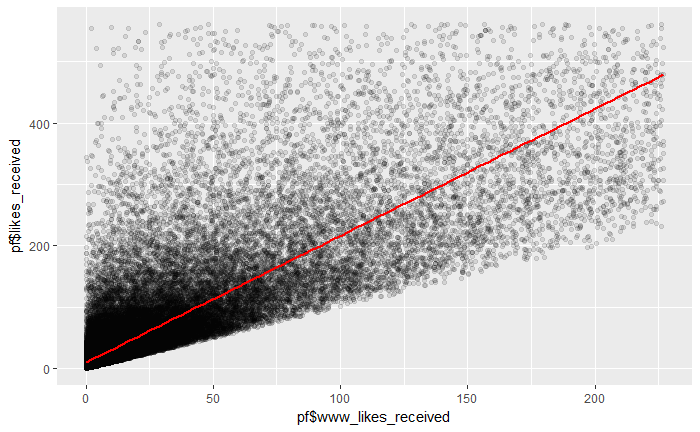

### Strong Correlations

Notes:

```r
cor.test(pf$www_likes_received, pf$likes_received)
```

```
    Pearson's product-moment correlation

data:  pf$www_likes_received and pf$likes_received
t = 937.1, df = 99001, p-value < 2.2e-16
alternative hypothesis: true correlation is not equal to 0
95 percent confidence interval:
 0.9473553 0.9486176
sample estimates:
      cor
0.9479902
```

What’s the correlation betwen the two variables? Include the top 5% of values for the variable in the calculation and round to 3 decimal places.

Response:

### Moira on Correlation

Notes:

### More Caution with Correlation

Notes:

```r
library(alr3)
```

Create your plot!

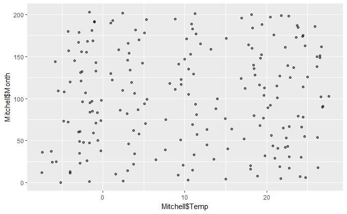

### Noisy Scatterplots

1. Take a guess for the correlation coefficient for the scatterplot.
2. What is the actual correlation of the two variables? (Round to the thousandths place)

```r
cor.test(Mitchell$Month, Mitchell$Temp)
```

```
    Pearson's product-moment correlation

data:  Mitchell$Month and Mitchell$Temp
t = 0.81816, df = 202, p-value = 0.4142
alternative hypothesis: true correlation is not equal to 0
95 percent confidence interval:
 -0.08053637  0.19331562
sample estimates:
       cor
0.05747063
```

### Making Sense of Data

Notes: - Months are discrete.

```r
range(Mitchell$Month)
```

```
[1]   0 203
```

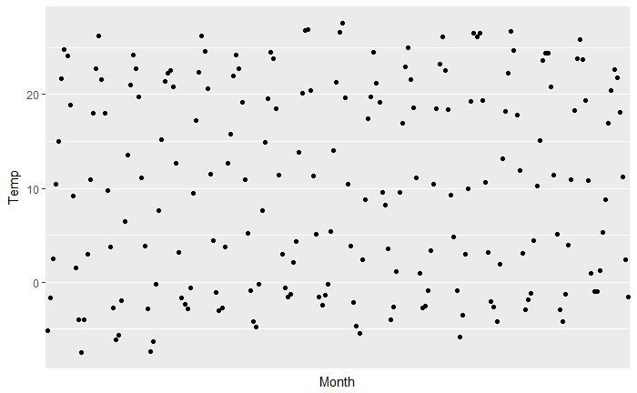

```r
ggplot(Mitchell, aes(x=Month, y=Temp)) +
  geom_point() +
  scale_x_discrete(breaks=seq(0,203,12))
```

### A New Perspective

What do you notice? Response:

Watch the solution video and check out the Instructor Notes! Notes:

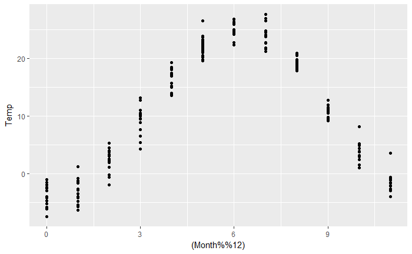

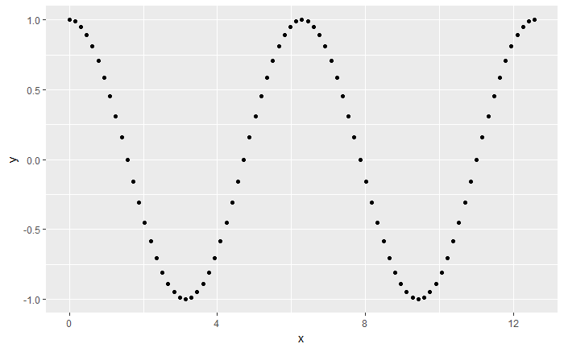

```r
ggplot(aes(x=(Month%%12),y=Temp), data=Mitchell)+
  geom_point()
x <- seq(0, 4*pi, pi/20)
y <- cos(x)
qplot(x = x, y = y)

dcor.ttest(x, y)
```

```
Error: could not find function "dcor.ttest"
```

### Understanding Noise: Age to Age Months

Notes:

```r
pf$age_with_months
```

[output not shown]

[output cut: 86 more lines]

### Age with Months Means

Programming Assignment

| age_with_months | friend_count_mean | friend_count_median | n |
| --- | --- | --- | --- |
| 13.16667 | 46.33333 | 30.5 | 6 |
| 13.25000 | 115.07143 | 23.5 | 14 |
| 13.33333 | 136.20000 | 44.0 | 25 |
| 13.41667 | 164.24242 | 72.0 | 33 |
| 13.50000 | 131.17778 | 66.0 | 45 |
| 13.58333 | 156.81481 | 64.0 | 54 |
| 13.66667 | 130.06522 | 75.5 | 46 |
| 13.75000 | 205.82609 | 122.0 | 69 |
| 13.83333 | 215.67742 | 111.0 | 62 |
| 13.91667 | 162.28462 | 71.0 | 130 |

[output cut: 990 more lines]

### Noise in Conditional Means

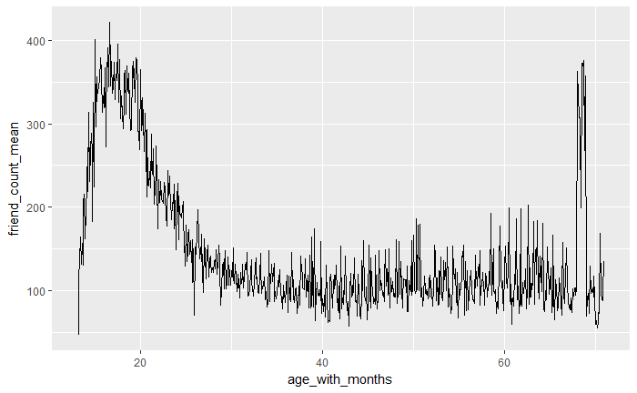

### Smoothing Conditional Means

Notes:

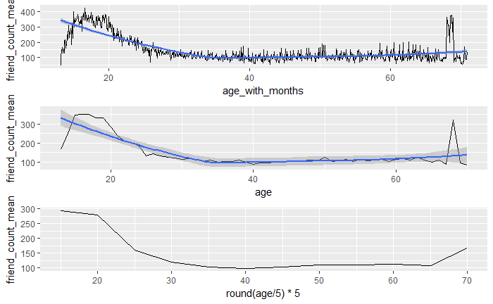

### Which Plot to Choose?

Notes:

### Analyzing Two Variables

Reflection: